# Fase 3.1: Implementación de Red Neuronal

**Integrantes:**

- José Villalta
- Daniel Collaguazo

**Fecha:** 22 de Octubre de 2024

**Actividad:** Implementación de una red neuronal básica para la clasificación de datos, previo a un proceso de optimización (fine-tuning).

## I. Importación de Librerías

Se importan las librerías necesarias para la creación y entrenamiento de la red neuronal. Entre ellas, se incluyen `tensorflow` y `keras` para la definición del modelo, además de otras bibliotecas auxiliares para la manipulación de datos.

```python
import pandas as pd
import numpy as np
import matplotlib.pyplot as plt

from time import time
from datetime import datetime, timedelta

from sklearn.impute import SimpleImputer
from sklearn.preprocessing import OneHotEncoder, StandardScaler, OrdinalEncoder, MinMaxScaler
from sklearn.compose import make_column_transformer, ColumnTransformer
from sklearn.pipeline import Pipeline
import pickle
import seaborn as sns
import copy

from sklearn.model_selection import train_test_split
from sklearn.model_selection import cross_val_score
from sklearn.model_selection import StratifiedKFold
from sklearn.model_selection import ShuffleSplit
from sklearn.model_selection import GridSearchCV
from keras.layers import Dropout

import keras
from keras.layers import Dense
from keras.models import Sequential
from keras.models import model_from_json
from keras.models import load_model

from sklearn import metrics
from sklearn.metrics import confusion_matrix
from sklearn.metrics import accuracy_score
from sklearn.metrics import precision_score
from sklearn.metrics import recall_score
from sklearn.metrics import f1_score

from sklearn import set_config

from imblearn.over_sampling import SMOTE
print("Módulos y clases importados")
```

```
Módulos y clases importados
```

## II. Carga y Preprocesamiento de Datos

Se carga el conjunto de datos previamente procesado en las fases anteriores. Aquí se ajustan las variables y se organizan en formato adecuado para ser utilizado por la red neuronal.

```python
# Cargar el dataset
dataframeTransformadoRN=pd.read_csv("DatasetTransformadoConEtiquetas.csv", sep=";")
print(dataframeTransformadoRN.shape)

dataframeTransformadoRN = dataframeTransformadoRN.dropna()
dataframeTransformadoRN['Revenue'] = dataframeTransformadoRN['Revenue'].astype(int)
dataframeTransformadoRN
```

```
(12330, 53)
```

|  | Month | OperatingSystems | Browser | Region_1 | Region_2 | Region_3 | Region_4 | Region_5 | Region_6 | Region_7 | ... | Administrative | AdministrativeDuration | Informational | InformationalDuration | ProductRelated | ProductRelatedDuration | BounceRate | ExitRate | PageValues | Revenue |
| --- | --- | --- | --- | --- | --- | --- | --- | --- | --- | --- | --- | --- | --- | --- | --- | --- | --- | --- | --- | --- | --- |
| 0 | -1.334959 | -1.233426 | -0.790293 | 1.256781 | -0.318564 | -0.492003 | -0.325619 | -0.162707 | -0.264288 | -0.256475 | ... | -0.696993 | -0.457191 | -0.396478 | -0.244931 | -0.691003 | -0.624348 | 3.667189 | 3.229316 | -0.317178 | 0 |
| 1 | -1.334959 | -0.136078 | -0.207952 | 1.256781 | -0.318564 | -0.492003 | -0.325619 | -0.162707 | -0.264288 | -0.256475 | ... | -0.696993 | -0.457191 | -0.396478 | -0.244931 | -0.668518 | -0.590903 | -0.457683 | 1.171473 | -0.317178 | 0 |
| 2 | -1.334959 | 2.058618 | -0.790293 | -0.795684 | -0.318564 | -0.492003 | -0.325619 | -0.162707 | -0.264288 | -0.256475 | ... | -0.696993 | -0.457191 | -0.396478 | -0.244931 | -0.691003 | -0.624348 | 3.667189 | 3.229316 | -0.317178 | 0 |
| 3 | -1.334959 | 0.961270 | -0.207952 | -0.795684 | 3.139088 | -0.492003 | -0.325619 | -0.162707 | -0.264288 | -0.256475 | ... | -0.696993 | -0.457191 | -0.396478 | -0.244931 | -0.668518 | -0.622954 | 0.573535 | 1.994610 | -0.317178 | 0 |
| 4 | -1.334959 | 0.961270 | 0.374389 | 1.256781 | -0.318564 | -0.492003 | -0.325619 | -0.162707 | -0.264288 | -0.256475 | ... | -0.696993 | -0.457191 | -0.396478 | -0.244931 | -0.488636 | -0.296430 | -0.045196 | 0.142551 | -0.317178 | 0 |
| ... | ... | ... | ... | ... | ... | ... | ... | ... | ... | ... | ... | ... | ... | ... | ... | ... | ... | ... | ... | ... | ... |
| 12325 | -1.756881 | 2.058618 | 2.121412 | 1.256781 | -0.318564 | -0.492003 | -0.325619 | -0.162707 | -0.264288 | -0.256475 | ... | 0.206173 | 0.363075 | -0.396478 | -0.244931 | 0.478227 | 0.307822 | -0.310366 | -0.288966 | 0.342125 | 0 |
| 12326 | 0.774654 | 0.961270 | -0.207952 | 1.256781 | -0.318564 | -0.492003 | -0.325619 | -0.162707 | -0.264288 | -0.256475 | ... | -0.696993 | -0.457191 | -0.396478 | -0.244931 | -0.601062 | -0.380957 | -0.457683 | -0.447364 | -0.317178 | 0 |
| 12327 | 0.774654 | 0.961270 | -0.207952 | 1.256781 | -0.318564 | -0.492003 | -0.325619 | -0.162707 | -0.264288 | -0.256475 | ... | -0.696993 | -0.457191 | -0.396478 | -0.244931 | -0.578577 | -0.528063 | 1.261014 | 0.897093 | -0.317178 | 0 |
| 12328 | 0.774654 | -0.136078 | -0.207952 | -0.795684 | -0.318564 | 2.032507 | -0.325619 | -0.162707 | -0.264288 | -0.256475 | ... | 0.507228 | -0.032916 | -0.396478 | -0.244931 | -0.376210 | -0.443536 | -0.457683 | -0.453140 | -0.317178 | 0 |
| 12329 | 0.774654 | 0.961270 | -0.207952 | 1.256781 | -0.318564 | -0.492003 | -0.325619 | -0.162707 | -0.264288 | -0.256475 | ... | -0.696993 | -0.457191 | -0.396478 | -0.244931 | -0.646033 | -0.613243 | -0.457683 | 0.485525 | -0.317178 | 0 |

12330 rows × 53 columns

```python
dataframeTransformadoRN.info()
```

```
<class 'pandas.core.frame.DataFrame'>
RangeIndex: 12330 entries, 0 to 12329
Data columns (total 53 columns):
 #   Column                         Non-Null Count  Dtype
---  ------                         --------------  -----
 0   Month                          12330 non-null  float64
 1   OperatingSystems               12330 non-null  float64
 2   Browser                        12330 non-null  float64
 3   Region_1                       12330 non-null  float64
 4   Region_2                       12330 non-null  float64
 5   Region_3                       12330 non-null  float64
 6   Region_4                       12330 non-null  float64
 7   Region_5                       12330 non-null  float64
 8   Region_6                       12330 non-null  float64
 9   Region_7                       12330 non-null  float64
```

[output cut: 45 more lines]

```python
#Funciones para guardar y cargar la Red Neuronal (Arquitectura y Pesos)
def guardarNN(model,nombreArchivo):
    print("Guardando Red Neuronal en Archivo")
    model.save(nombreArchivo+'.h5')
    print("Red Neuronal Grabada en Archivo")

def cargarNN(nombreArchivo):
    model = load_model(nombreArchivo+'.h5')
    print("Red Neuronal Cargada desde Archivo")
    return model
```

```python
def cargarPipeline(nombreArchivo):
    with open(nombreArchivo+'.pickle', 'rb') as handle:
        pipeline = pickle.load(handle)
    return pipeline
```

```python
nombreArchivoPreprocesador='pipePreprocesadores'
pipe=None
pipe=cargarPipeline(nombreArchivoPreprocesador) #Debes incluir el archivo del Pipeline en el mismo directorio del script
cantidadPasos=len(pipe.steps)
print("Cantidad de pasos: ",cantidadPasos)
set_config(display='diagram')
pipe
```

```
Cantidad de pasos:  3
```

```
Pipeline(steps=[('prepcn',
                 ColumnTransformer(remainder='passthrough',
                                   transformers=[('catord',
                                                  Pipeline(steps=[('ordinal',
                                                                   OrdinalEncoder())]),
                                                  ['Month', 'OperatingSystems',
                                                   'Browser']),
                                                 ('catnom',
                                                  Pipeline(steps=[('onehot',
                                                                   OneHotEncoder(handle_unknown='ignore',
                                                                                 sparse_output=False))]),
                                                  ['Region', 'TrafficType',
                                                   'VisitorType', 'Weekend',
                                                   'SpecialDay'])])),
                ('prepstandard', StandardScaler()),
                ('prepsimpleimputer', SimpleImputer(strategy='median'))])
```

## III. Normalización y balanceo de los datos

En esta sección, Separamos la variable de salida asi como SMOTE para el balanceo de los datos y tener una mejor información previa al entrenamiento.

```python
Y = dataframeTransformadoRN['Revenue']
dataframeTransformadoRN = dataframeTransformadoRN.drop(['Revenue'], axis=1)
X_Transformado = dataframeTransformadoRN.values
```

```python
# SMOTE para balanceo de datos
smote = SMOTE()
X_resampled, y_resampled = smote.fit_resample(X_Transformado, Y)
sample_size = 0.5  # O ajusta al tamaño que prefieras

# Tomar la muestra estratificada para mantener el balance de clases
X_sampled, _, y_sampled, _ = train_test_split(X_resampled, y_resampled,
                                              train_size=sample_size,
                                              stratify=y_resampled,
                                              random_state=42)
```

```
Distribución de clases antes del balanceo:
Revenue
0    10422
1     1908
Name: count, dtype: int64
```

```
Distribución de clases después del balanceo:
Revenue
0    10422
1    10422
Name: count, dtype: int64
```

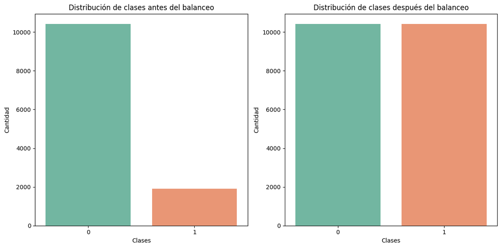

```python
# Contar el número de muestras por cada clase antes y después del balanceo
print("Distribución de clases antes del balanceo:")
print(pd.Series(Y).value_counts())
plt.figure(figsize=(12, 6))
plt.subplot(1, 2, 1)
sns.countplot(x=pd.Series(Y), palette="Set2")
plt.title("Distribución de clases antes del balanceo")
plt.xlabel("Clases")
plt.ylabel("Cantidad")

print("Distribución de clases después del balanceo:")
print(pd.Series(y_resampled).value_counts())
plt.subplot(1, 2, 2)
sns.countplot(x=pd.Series(y_resampled), palette="Set2")
plt.title("Distribución de clases después del balanceo")
plt.xlabel("Clases")
plt.ylabel("Cantidad")
plt.tight_layout()
plt.show()
```

## IV. Definición de la Arquitectura de la Red Neuronal

En esta sección, se construye la arquitectura de la red neuronal utilizando capas `Dense`, activaciones `relu`, y una capa de salida con activación `sigmoid` para la clasificación binaria. La red neuronal cuenta con varias capas ocultas para la captura de patrones complejos.

```python
X_train, X_test, y_train, y_test = train_test_split(X_sampled, y_sampled, test_size = 0.2, random_state=42)
```

```python
# Función para crear el modelo
def crear_modelo(input_dim, optimizer='adam', activation='relu', layers=[24, 12, 6]):
    model = Sequential()
    model.add(Dense(layers[0], input_dim=input_dim, activation=activation))
    for layer in layers[1:]:
        model.add(Dense(layer, activation=activation))
    model.add(Dense(1, activation='sigmoid'))
    model.compile(optimizer=optimizer, loss='binary_crossentropy', metrics=['accuracy'])

    #imprimir arquitectura de la red
    model.summary()
    return model
```

```python
# Parámetros iniciales
input_dim = X_train.shape[1]
modelo = crear_modelo(input_dim)
```

```
Model: "sequential"
```

```
┏━━━━━━━━━━━━━━━━━━━━━━━━━━━━━━━━━━━━━━┳━━━━━━━━━━━━━━━━━━━━━━━━━━━━━┳━━━━━━━━━━━━━━━━━┓
┃ Layer (type)                         ┃ Output Shape                ┃         Param # ┃
┡━━━━━━━━━━━━━━━━━━━━━━━━━━━━━━━━━━━━━━╇━━━━━━━━━━━━━━━━━━━━━━━━━━━━━╇━━━━━━━━━━━━━━━━━┩
│ dense (Dense)                        │ (None, 24)                  │           1,272 │
├──────────────────────────────────────┼─────────────────────────────┼─────────────────┤
│ dense_1 (Dense)                      │ (None, 12)                  │             300 │
├──────────────────────────────────────┼─────────────────────────────┼─────────────────┤
│ dense_2 (Dense)                      │ (None, 6)                   │              78 │
├──────────────────────────────────────┼─────────────────────────────┼─────────────────┤
│ dense_3 (Dense)                      │ (None, 1)                   │               7 │
└──────────────────────────────────────┴─────────────────────────────┴─────────────────┘
```

```
 Total params: 1,657 (6.47 KB)
```

```
 Trainable params: 1,657 (6.47 KB)
```

```
 Non-trainable params: 0 (0.00 B)
```

## V. Entrenamiento de la Red Neuronal

El modelo se entrena utilizando el conjunto de entrenamiento. Se emplean múltiples epochs y un tamaño de lote predefinido para mejorar la capacidad predictiva de la red.

```python
# Entrenamos
history = modelo.fit(X_train, y_train, epochs=350, batch_size=80, validation_data=(X_test, y_test))

score = modelo.evaluate(X_train, y_train, verbose=0)
print('Resultado en Train:')
print("%s: %.2f%%" % (modelo.metrics_names[1], score[1]*100))

#Fase de Testing
score = modelo.evaluate(X_test, y_test, verbose=0)
print('Resultado en Test:')
print("%s: %.2f%%" % (modelo.metrics_names[1], score[1]*100))

#nombreArchivoRedNeuronal='RNBalanceado'
#guardarRNN(modelo,nombreArchivoRedNeuronal)


modelo.save('RNBalanceadoOP.keras', include_optimizer=False)
# Evaluar el modelo
y_pred = (modelo.predict(X_test) >= 0.5).astype(int)
accuracy = accuracy_score(y_test, y_pred)
precision = precision_score(y_test, y_pred)
recall = recall_score(y_test, y_pred)
f1 = f1_score(y_test, y_pred)

print(f'Accuracy: {accuracy}')
print(f'Precision: {precision}')
print(f'Recall: {recall}')
print(f'F1-Score: {f1}')
```

[output not shown]

[output cut: 304 more lines]

```
105/105 ━━━━━━━━━━━━━━━━━━━━ 0s 3ms/step - accuracy: 0.9540 - loss: 0.1234 - val_accuracy: 0.8873 - val_loss: 0.4932
105/105 ━━━━━━━━━━━━━━━━━━━━ 0s 2ms/step - accuracy: 0.9589 - loss: 0.1131 - val_accuracy: 0.8902 - val_loss: 0.4897
105/105 ━━━━━━━━━━━━━━━━━━━━ 0s 3ms/step - accuracy: 0.9593 - loss: 0.1085 - val_accuracy: 0.8820 - val_loss: 0.5154
105/105 ━━━━━━━━━━━━━━━━━━━━ 0s 4ms/step - accuracy: 0.9612 - loss: 0.1090 - val_accuracy: 0.8806 - val_loss: 0.5014
105/105 ━━━━━━━━━━━━━━━━━━━━ 0s 4ms/step - accuracy: 0.9585 - loss: 0.1108 - val_accuracy: 0.8868 - val_loss: 0.5070
105/105 ━━━━━━━━━━━━━━━━━━━━ 0s 4ms/step - accuracy: 0.9553 - loss: 0.1178 - val_accuracy: 0.8892 - val_loss: 0.4962
Resultado en Train:
compile_metrics: 96.52%
Resultado en Test:
compile_metrics: 88.92%
66/66 ━━━━━━━━━━━━━━━━━━━━ 0s 3ms/step
Accuracy: 0.8892086330935252
Precision: 0.8860294117647058
Recall: 0.900093370681606
F1-Score: 0.8930060213061602
```

## VI. Evaluación del Modelo

Se evalúa el desempeño de la red neuronal en el conjunto de prueba, obteniendo métricas como la precisión y la pérdida del modelo. Esto proporciona una primera idea del rendimiento de la red antes de realizar optimizaciones adicionales.

```
Mean Absolute Error (MAE): 0.1108
Mean Squared Error (MSE): 0.1108
Root Mean Squared Error (RMSE): 0.3329
Accuracy: 0.8892086330935252
Precision:  0.886
Recall:  0.9001
F1: 0.893
Matriz de confusión:
Verdaderos negativos:  890  Falsos positivos:  124  Falsos negativos:  107  Verdaderos positivos:  964
```

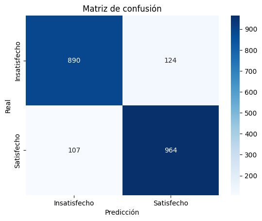

```python
MAE=metrics.mean_absolute_error(y_test, y_pred)
MSE=metrics.mean_squared_error(y_test, y_pred)
RMSE=np.sqrt(metrics.mean_squared_error(y_test, y_pred))

MAE=str(round(MAE, 4))
MSE=str(round(MSE, 4))
RMSE=str(round(RMSE, 4))

print('Mean Absolute Error (MAE):', MAE)
print('Mean Squared Error (MSE):', MSE)
print('Root Mean Squared Error (RMSE):', RMSE)

y_testBinario = (y_test >= 0.5).astype("int32")
y_predBinario = (y_pred >= 0.5).astype("int32")

#y_pred=y_pred.flatten()# de 2D a 1D

accuracyModeloBase=str(accuracy_score(y_testBinario, y_predBinario))
print('Accuracy: ' + accuracyModeloBase)

precision=precision_score(y_testBinario, y_predBinario)
precision=str(round(precision, 4))
print('Precision: ',precision)

recall=recall_score(y_testBinario, y_predBinario)
recall=str(round(recall, 4))
print('Recall: ',recall)

f1=f1_score(y_testBinario, y_predBinario)
f1=str(round(f1, 4))
print('F1:',f1)

print('Matriz de confusión:')
tn, fp, fn, tp = confusion_matrix(y_testBinario, y_predBinario).ravel()
print('Verdaderos negativos: ',tn,' Falsos positivos: ',fp,' Falsos negativos: ',fn,' Verdaderos positivos: ',tp)

from sklearn.metrics import confusion_matrix
labels = ['Insatisfecho', 'Satisfecho']
cm = confusion_matrix(y_testBinario, y_predBinario)
ax= plt.subplot()
sns.heatmap(cm, annot=True, ax = ax, cmap='Blues', fmt='g'); #annot=True to annotate cells
ax.set_xlabel('Predicción');ax.set_ylabel('Real');
ax.set_title('Matriz de confusión');
ax.xaxis.set_ticklabels(labels); ax.yaxis.set_ticklabels(labels);
```

## Conclusiones

La implementación básica de la red neuronal ha logrado un desempeño aceptable en términos de precisión, aunque aún presenta áreas de mejora. Dado que se trata de un modelo inicial sin fine-tuning, es probable que la red no esté completamente optimizada y pueda beneficiarse de técnicas como la búsqueda de hiperparámetros, el ajuste de la arquitectura, o el uso de regularización para evitar sobreajuste. En general, la red ha capturado los patrones básicos del conjunto de datos, y los siguientes pasos se centrarán en mejorar su rendimiento a través de ajustes finos.